# Why and How to Think with AI

## Why and How to Think with AI

Today you will create your own AI agent and use it to think.

[timgasste.github.io/ai-thinking](https://timgasste.github.io/ai-thinking/)

Before we start, open this page on your laptop and follow **Get ready**: download ChatGPT, create an account, and set up your folder. More on that in the lecture.

Tim Gåsste

Department of Peace and Conflict Research

Uppsala University

## Will AI Take Your Job?

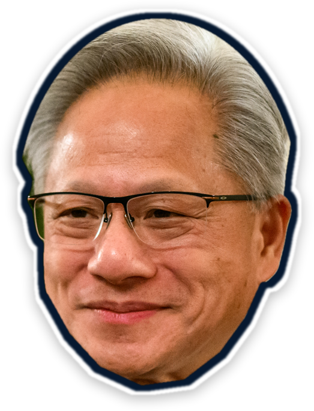

Jensen HuangCEO, Nvidia

You're not going to lose your job to an AI, but you're going to lose your job to **someone who uses AI**.

Milken Institute Global Conference, 6 May 2025, as reported by CNBC. Photo: The White House (public domain).

## The Overhang

Ethan Mollick calls it *the overhang*: “the gap between what these models can do and what almost anyone is doing with them.”

[figure not shown]

Conceptual illustration, not data. Quote: Ethan Mollick, “The Overhang,” *One Useful Thing*, 18 September 2026.

## Your Capacity to Think Is the Bottleneck

- AI increasingly does the execution: searching, drafting, coding, summarizing.
- What it multiplies is what you bring: **specialized and general knowledge, coupled with creativity, taste, and judgment.**
- All of these are built by thinking and learning. That is the bottleneck, and it is yours to widen.

[figure not shown]

## AI moves the hard thinking upstream

AI moves the hard thinking **upstream**: into framing, judging, and deciding. Without expertise, you get **polished slop**.

## Knowledge matters more, not less

Working at a higher level of abstraction does not make knowledge less important. **It does the opposite.**

Case in point · NPR, 7 July 2026

“Why AI companies are hiring philosophers to help develop their models”

Anthropic and Google bring in philosophers to help shape how their models reason and behave.

## Become a Unicorn

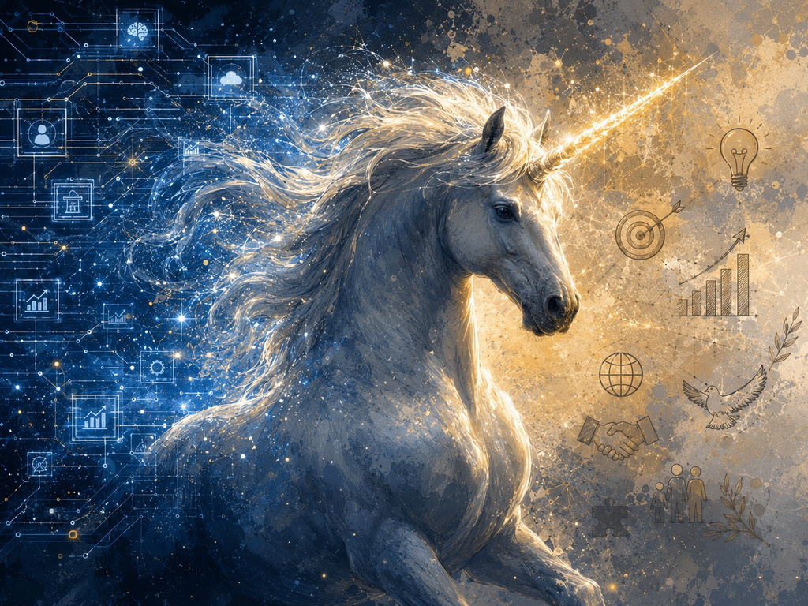

Four human advantages that AI multiplies

Deep knowledge

Expertise so thorough it becomes intuition. You sense when something is wrong.

Wide knowledge

Read across fields, formats, and traditions. It helps you understand and ask the right questions.

Taste

AI makes output abundant. Choosing well is the scarce skill.

Agency

Explore what AI can do in your field. Nobody has mapped it yet.

The four advantages are from Ethan Mollick, “The Overhang,” *One Useful Thing*, 18 September 2026.

## The Challenge

AI makes thinking scalable and **more important** than ever

AI misuse **weakens** your capacity to think, learn, and be creative

The goal: use AI to **raise the quality of your work while strengthening your own capacity** to think, learn, and create.

## Roadmap

- Why now: knowledge matters more
- From assistant to agent, with Exercise 1
- 15-minute break
- Put your agent to work, with Exercise 2
- Outsource the work, not the thinking
- Takeaways

## The Goal

I have one main goal with this lecture: to help you learn how to work with **AI agents** to improve your **capacity to think** and your **ability to learn**!

## Important information

Important information

This is an inspirational lecture on thinking with AI. It discusses practical AI workflows, but it is **not a general permission to use AI in your studies**. Always follow the AI instructions, rules, and regulations for your course module. When in doubt, ask the course convener for exact guidance.

The views and workflows are my own. They build on public AI commentators, credited at the end.

## Get Ready While We Talk

Now, in the background

You will need this in Exercise 1. The download runs while we talk.

1

Download the **ChatGPT desktop app** for Mac, Windows, or Linux. The link is on the lecture page.

2

Open it and **create a free account**, or log in. **Free is enough for today.**

3

Download the ready-made **`ai-lab` folder** and unzip it into your **Documents** folder.

Open on your laptop

[timgasste.github.io/ai-thinking](https://timgasste.github.io/ai-thinking/)

Download links, prompts, the starter folder, and these slides

**Stuck, or just curious?** Ask at any point. There are no stupid questions about AI.

## Quick Poll: How Do You Use AI Today?

2 minutes, on your phone

While the app downloads on your laptop. Anonymous.

[figure not shown]

1Take out your **phone**.

2**Scan the code**, or open menti.com/al7tbh775af3

3Answer **four quick statements**.

Results appear live on the next slide.

## Quick Poll: Live Results

**Join the poll**menti.com/al7tbh775af3

[figure not shown]

**Live results appear here during the lecture**Scan the code on the previous slide to take part.

# From Assistant to Agent

## AI Tool Map (Click Tools to Explore)

General assistants

Reasoning, drafting, comparison, feedback, and broad task support.

Search and sources

Find current information and check answers against sources.

Literature

Discovery, citation context, and evidence assessment.

Writing and references

Language polish and reference management.

Coding agents

Work in project folders: files, code, analysis, and tests.

Transcription and voice

Speech capture, transcription, dictation, and generated audio.

OpenAI

ChatGPT + Codex + Whisper

Anthropic

Claude + Claude Code

Gemini

Workspace + Code Assist

Grok

Grok Build

Microsoft Copilot

Perplexity

NotebookLM

now Gemini Notebook

Elicit

Semantic Scholar

Scite

Litmaps

Zotero

Grammarly

GitHub Copilot

Cursor

Otter

My daily tool

Wispr Flow

ElevenLabs

Start here

Choose one of these, use it, and learn it well. This is where you get the most value for the least effort.

Answers only from your sources

NotebookLM (now Gemini Notebook) answers from the documents you give it and cites the passage behind each answer. Use it when nothing else should creep in: a contract, a court ruling, a policy, or your cleared course readings.

## From Prompt Engineering to Question Engineering

Then: prompt engineering

Templates, step-by-step chains, and long rule lists that **walked the model through the task**.

Now: question engineering

Frame a great question: a clear goal, real context, and your standard of quality. **Then let the model plan the steps.**

You do not need intricate prompt strategies. You need great questions. Strong models plan better than our scripts, and over-specifying imposes our own, often flawed, framing of the problem.

Then/now contrast based on Ethan Mollick, “The Dot and the Swarm,” *One Useful Thing*, 1 October 2026.

## Anatomy of a Good Question

1

Task

2

Purpose

3

Context

4

Material

5

Constraints

6

Format

7

Evaluation

8

Interaction

Written out in full. Most questions need only a few of these.

(1) Help me assess whether political exclusion increases the risk of organized political violence. (2) I want to sharpen a research question before drafting a theory section, not receive a finished argument. (3) I am working in peace and conflict research and preparing a graduate seminar memo, so focus on mechanisms, scope conditions, alternative explanations, and observable implications. (4) Use only the notes and source excerpts I paste below. (5) Separate author claims from your inferences, mark unsupported claims as "needs source", and do not invent citations. (6) Return a four-step causal pathway, two counterarguments, three questions I must answer, and one next prompt. (7) A strong answer is specific, source-bounded, mechanism-focused, and honest about uncertainty. (8) Ask one clarifying question if needed, then wait for my response before revising the research question.

Ask

Research mode

## Vibe Coding or Agentic Engineering?

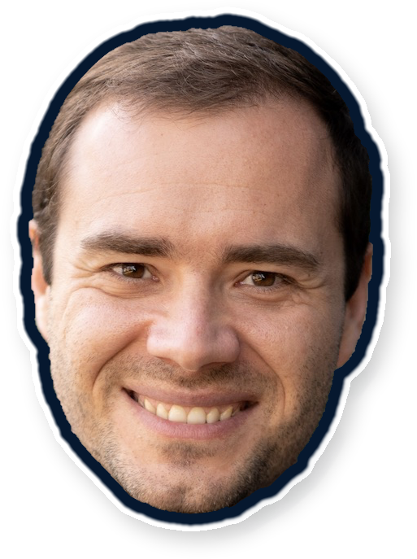

Andrej Karpathy

## Vibe Coding or Agentic Engineering?

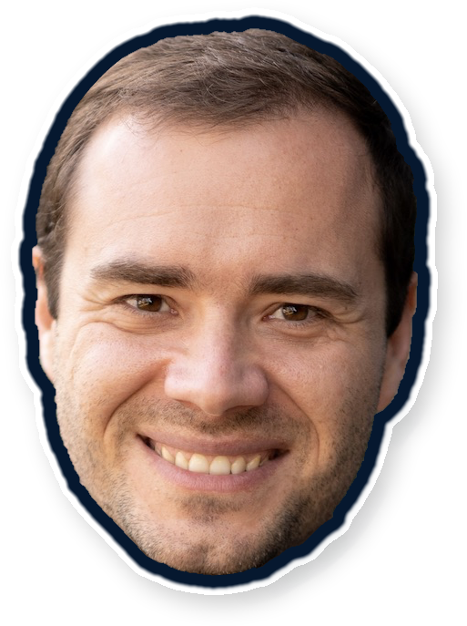

Andrej Karpathy

Vibe coding

**AI leads.** The human steers by feel, accepts plausible output, and may miss errors, structure, and consequences.

Agentic engineering

**AI executes.** The human reviews, tests, and remains the architect, evaluator, and accountable author.

## The Basics of Agentic Engineering I

Model

A large language model that turns what you give it into an answer. Reasoning models think longer and check their own work.

Agent

A model working in a loop. It uses tools and files, checks the results, and keeps going until the task is done.

Harness

Everything around the model that keeps it on track, including instructions, files, tools, permissions, and memory.

## The Basics of Agentic Engineering II

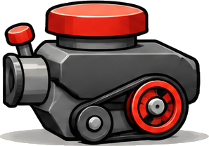

Conventional model

Core language model

**Examples:** ChatGPT Instant and Claude Haiku 5.5

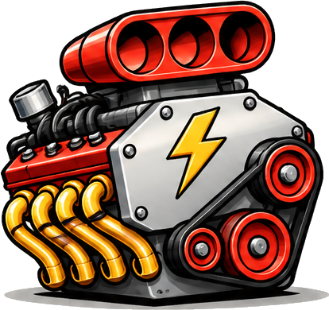

Reasoning model

Thinks longer before it answers

**Examples:** GPT-6 at high effort and Claude Opus 5.5

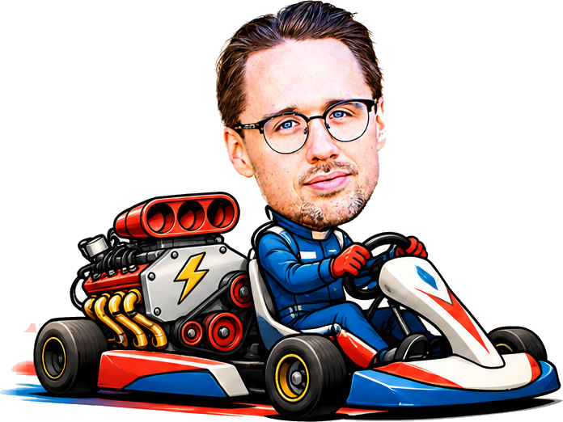

Reasoning model in an agent harness

Model plus tools, files, memory, and feedback

**Examples:** ChatGPT Work, Codex, or Claude Code in a local project folder with clear instructions, relevant files, tools, saved outputs, and human review

Adapted from [Sebastian Raschka’s blog post and figure](https://magazine.sebastianraschka.com/p/components-of-a-coding-agent).

## From Chatbot to Agent

One of the greatest leaps in how we can use AI: deploy your agent where the work lives.

Chatbot

The way most people use AI

- Answers when you paste material in.
- You move text, files, and results in and out.
- Best for dialogue, critique, explanation, and quick drafting.

Agent

The most powerful way to use AI

- Works inside a chosen project folder.
- Can read your readings and notes, code interview transcripts, run statistics, and save outputs.
- Best for multi-step research tasks that need files, tools, and review.

Build Your Harness

Start with a bounded local project folder. Add clear instructions, relevant files, tool permissions, and saved outputs. You remain the director. Define the goal, guide execution, and decide what gets used.

Choose a Tool

Use a tool that fits your purpose.

It must support agentic work.

It should run in a local project folder.

## Basic Setup: Folder, Agent, Instructions

1 A folder on your computer

An ordinary folder in **Finder or File Explorer**, not something inside the AI app. You choose which folder the agent may open.

Reads the files

↓

Works on the task, step by step

↓

Saves new files

↓

You check and decide

2 The app deploys an agent

Create a project from that folder, and the app does more than chat. Its agent reads, works, and saves there. You stay the director.

You type (.md)

# About me - MSc student - Quiz me first

It means

About me

MSc student

Quiz me first

3 Instructions in a text file

**Markdown** (`.md`) is plain text with a few marks: `#` for a heading, `-` for a bullet. Models read it most reliably.

**Prefer Word to Markdown, or Excel to `.csv`?** That is completely fine. What matters is that the model gets your information as text and numbers, in a form that fits you and your workflow.

## Setting It Up and Using It Responsibly

One project folder. One tool connected to it. One thinking-oriented loop.

Set up the working folder

project/

|--sources/

|--working/

|--outputs/

|--LOG.md

+--INSTRUCTIONS.md

Use one standing instructions file, such as `INSTRUCTIONS.md` (a Word file works too). Give access to this folder, not your whole computer.

Run it where the work lives

Use the desktop app rather than only the browser chat. On large jobs, ask for the plan before it runs.

Apply a thinking-oriented workflow

**Plan** → **Prompt** → **Evaluate**  
**Revise** → **Produce** → **Learn**

Tool choice

Start free with the ChatGPT desktop app and its Work mode. For more, pick one paid stack and learn it well.

**OpenAI** — ChatGPT + Codex

**Anthropic** — Claude + Claude Code

Confidentiality and Copyright

Do not send confidential data or copyrighted material without approval or clearance.

File access

The tool can edit files. Keep `sources/` read‑only. Require approval before overwriting files or making larger revisions.

Verification

Instruct the tool to double-check claims and citations and never invent sources. You remain responsible. Check every number, quote, and source yourself.

## Exercise Preparation: Open Your Folder in ChatGPT

[figure not shown]

1

Choose **Work** at the top, then click the **+** next to Projects.

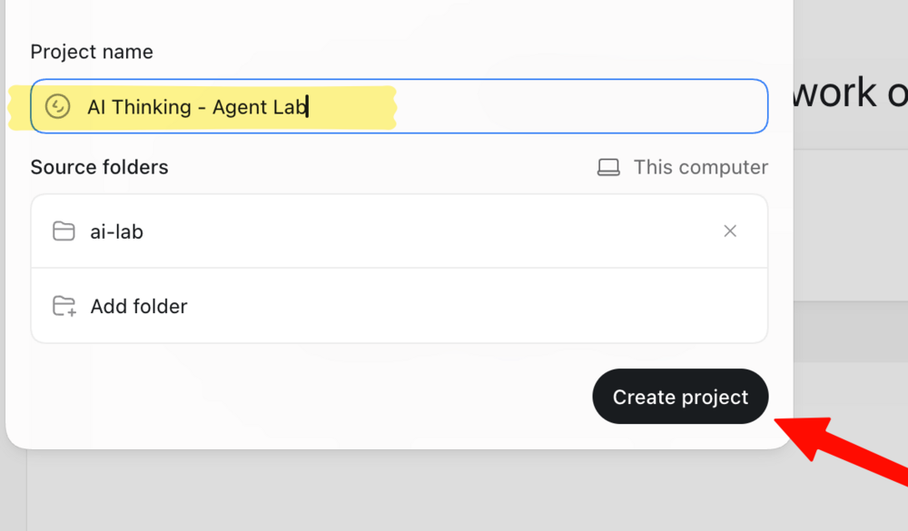

2

Click **Add folder**, pick **ai-lab** in Documents, and click **Open**. Give the project any name at the top, then click **Create project**.

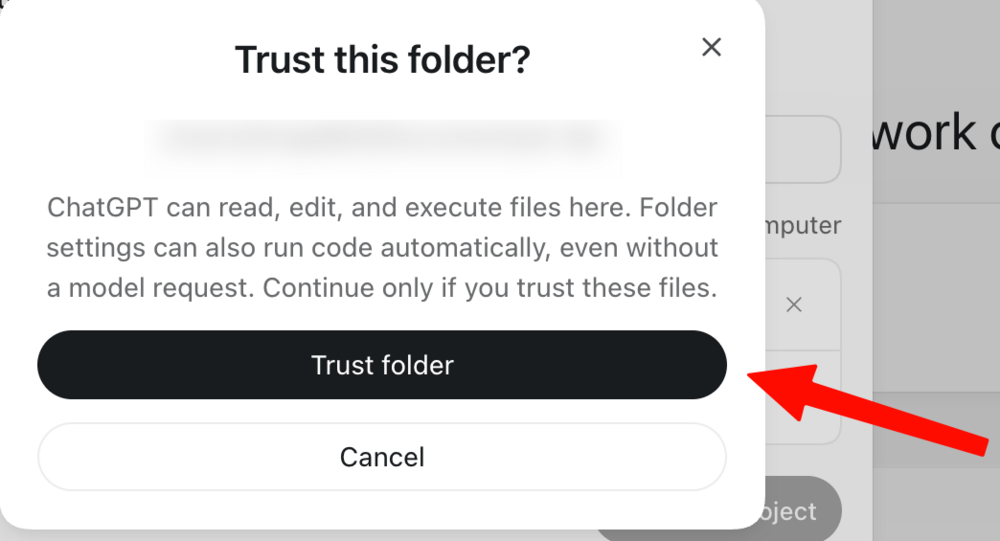

3

Click **Trust folder**. The agent can now read and save files in the ai-lab folder on your computer, and nowhere else.

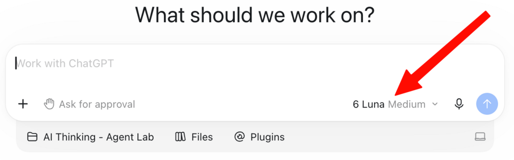

4

Ready. Keep **Ask for approval** on and the default model. Then paste your first task.

These steps are also on the lecture page: [timgasste.github.io/ai-thinking](https://timgasste.github.io/ai-thinking/)

## Exercise 1: Set Up Your Local Agent!

Prompts and help, on your laptop

[timgasste.github.io/ai-thinking](https://timgasste.github.io/ai-thinking/)

10 minutes

Build the harness you will use for the rest of the lecture. Help your neighbor if you finish early.

1

Find the `ai-lab` folder in your **Documents** folder. No download? Create a normal folder called `ai-lab` there, with subfolders `sources` and `outputs`.

2

In the **ChatGPT desktop app**, choose **Work** and **create a project** from `ai-lab`, as on the last slide. Another app whose agent can work in a folder works too.

3

Give it the task on the right, and **answer its five questions**. Short answers are fine.

4

Open `INSTRUCTIONS.md` (or `.docx`). **Check it, and change one thing yourself.**

Your first task

Interview me with five short questions, one at a time, about my studies, my goals, and how I want you to help me learn. Then save my answers and these rules as `INSTRUCTIONS.md` in this folder: use only files in this folder, never invent sources, and ask before you overwrite a file.

+Work · ai-lab

**Prefer Word?** Ask for `INSTRUCTIONS.docx` instead (about a minute slower). Markdown (`.md`) is plain text, which models read most reliably.

ai-lab/

|--**INSTRUCTIONS.md**← your harness

|--sources/

+--outputs/

**Struggling to get the agent working on your computer?** Pair up with a neighbor, or paste the task into a normal chat and save the answer as `INSTRUCTIONS.md` (or `.docx`) yourself.

## 15-Minute Break

15-minute break

Questions are welcome before you go, and there are no stupid ones.

# Put Your Agent to Work

## Agentic Engineering: Summary

Powerful and accessible

Today we use a free, lighter model. With a stronger model and a creative agent setup, the sky is the limit.

Model + harness + context

The human guides the work, and the harness gives the model context, tools, and feedback. They turn a powerful motor into a race car with a driver.

Responsibility scales too

As agentic setups gain more access, security and ethics matter even more. Make them part of the setup from the start.

## Let’s use agentic engineering to think and learn

Now let’s put agentic engineering to work: **to think better and learn more.**

## Example I: Your Study Partner

Turn cleared course material into active practice that fits you.

1 Folder

study-partner/

|--**INSTRUCTIONS.md**

|--sources/

+--cleared readings, notes, slides (PDF, Word, or text)

+--outputs/

|--flashcards.csv

|--quiz.md

+--weak-spots.md

2 Ask it for

Socratic tutoring

Explanations at your level

Flashcards for your gaps

Audio scripts to listen to

Voice: talk it through

A scheduled weekly digest

3 Prompt

Read my INSTRUCTIONS file. Using only `sources/`, quiz me on the hardest concept, one question at a time, and wait for my answer before you explain. Each time I get one wrong, add a flashcard to `outputs/` right away.

+Work · study-partner

**You still do the learning.** Answer before you look, and check every card against the source.

## Example II: Your Sparring Partner

Challenge your argument before it becomes text.

1 Folder

argument-review/

|--**INSTRUCTIONS.md**

|--sources/

|--working/

+--outline.md

+--outputs/

|--steelman.md

|--weak-links.md

+--revision-log.md

2 Ask it to

Steelman the other side

Find unsupported leaps

Expose vague concepts

Predict reader pushback

3 Prompt

Read my INSTRUCTIONS file and `working/outline.md`. Do not rewrite my text. Save a steelman of the strongest objection and a list of my unsupported leaps to `outputs/` first. Then ask me three hard questions.

+Work · argument-review

**The AI critiques. You revise and write.** Rerun the critique after each revision.

## Exercise 2: Put Your Agent to Work

Prompts and help, on your laptop

[timgasste.github.io/ai-thinking](https://timgasste.github.io/ai-thinking/)

10 minutes

Use this lecture’s PDF in `sources/`, or add your own notes (Word files are fine). Then pick one option. One is enough.

A

Study partner

Practice retrieval on something you need to know.

Read my INSTRUCTIONS file. Quiz me on [concept] using only `sources/`, three questions, one at a time. Each time I get one wrong, add a flashcard to `outputs/` right away.

Saves `outputs/flashcards.csv`

B

Sparring partner

Stress-test an argument you are working on.

Read my INSTRUCTIONS file. Steelman the strongest objection to [my argument] and list my unsupported leaps. Do not rewrite my text. Save it to `outputs/` first, then show me.

Saves `outputs/steelman.md`

C

Explain and listen

Get a hard idea explained the way you learn best.

Read my INSTRUCTIONS file. Explain [hard concept] from `sources/` at my level, as a three-minute script I can listen to. Save it to `outputs/` first, then show me.

Saves `outputs/explainer.md`

**Done early?** Try another option. **Afterwards:** tell your neighbor one thing the agent got wrong, or one thing you now understand better.

# Outsource the Work, Not the Thinking

## A Loop or a Spiral?

[figure not shown]

## Thinking Compounds

## Ultimately, Make the Knowledge Yours!

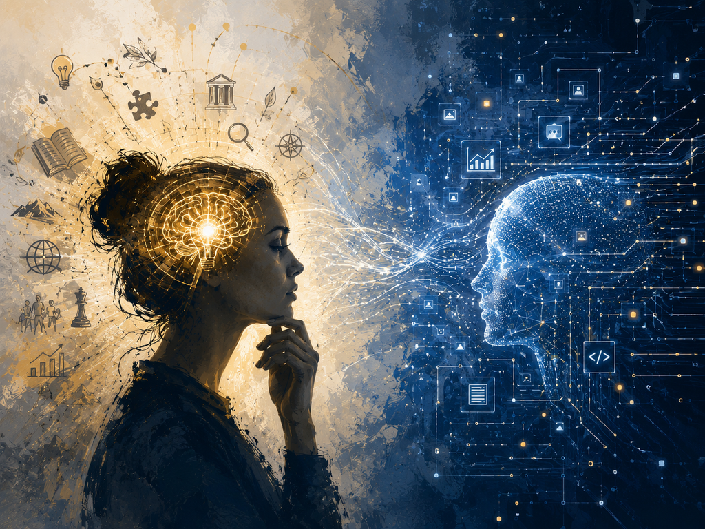

- Can I explain each claim and the reasoning behind it?
- Are the claims underpinned by credible evidence?
- Do I fully understand the method I am using?
- Can I defend all the choices in the work I submit?
- Am I developing my own capacity to think, learn, and be productive, and am I using AI to amplify it?

## Takeaways

1

AI moves the hard thinking upstream. **Knowledge, taste, and judgment matter more, not less.**

2

**Your capacity to think is the bottleneck.** Build deep and wide knowledge, and explore with agency.

3

**Start with one general assistant**, learn it well, and frame great questions. That is the most value for the least effort.

4

**Agentic engineering** puts the model in a harness: one folder, clear instructions, and your review. **Start free today.**

5

**Outsource the work, not the thinking.** Thinking-oriented use is a spiral, and it compounds.

6

**Make the knowledge yours.** If you cannot explain and defend it, it is not yours yet.

## Built On

The views and workflows in this lecture are my own. Many of the ideas build on these commentators, and I recommend following them.

Why knowledge matters

**Ethan Mollick** (2026). “The Overhang.” *One Useful Thing*, 18 September. oneusefulthing.org/p/the-overhang

**Ethan Mollick** (2026). “The Dot and the Swarm.” *One Useful Thing*, 1 October. oneusefulthing.org/p/the-dot-and-the-swarm

Agentic engineering

**Andrej Karpathy** coined “vibe coding” (February 2025) and proposed “agentic engineering” (February 2026) in posts on X.

**Sebastian Raschka** (2026). “Components of a Coding Agent.” *Ahead of AI*, 4 April. [magazine.sebastianraschka.com](https://magazine.sebastianraschka.com/p/components-of-a-coding-agent)

Quotes, news, and listening

**Jensen Huang** (2025). Remarks at the Milken Institute Global Conference, 6 May. Reported by CNBC, 28 May.

**NPR** (2026). “Why AI companies are hiring philosophers to help develop their models.” *All Things Considered*, 7 July.

**Jonas von Essen and Benjamin Verbeek.** *AI med Jonas & Benjamin* (podcast, in Swedish). Jonas von Essen on YouTube: youtube.com/@BlueberryClubSparven

Image credit: Jensen Huang, official White House photo by Daniel Torok (public domain), cropped.

## Questions?

[figure not shown]

1**Ask out loud**, any question.

2Rather not ask in front of everyone? **Scan the code** or open menti.com/al446n8s1z42 and type it there.

3Please share **two minutes of feedback**.

Answers appear live on the next slide.

## Your Questions and Feedback

**Questions and feedback**menti.com/al446n8s1z42

[figure not shown]

**Live answers appear here during the lecture**Scan the code on the previous slide to take part.

## Thank you!

Tim Gåsste

Department of Peace and Conflict Research Uppsala University

tim.gasste@pcr.uu.se

Slides, prompts, and links: [timgasste.github.io/ai-thinking](https://timgasste.github.io/ai-thinking/)

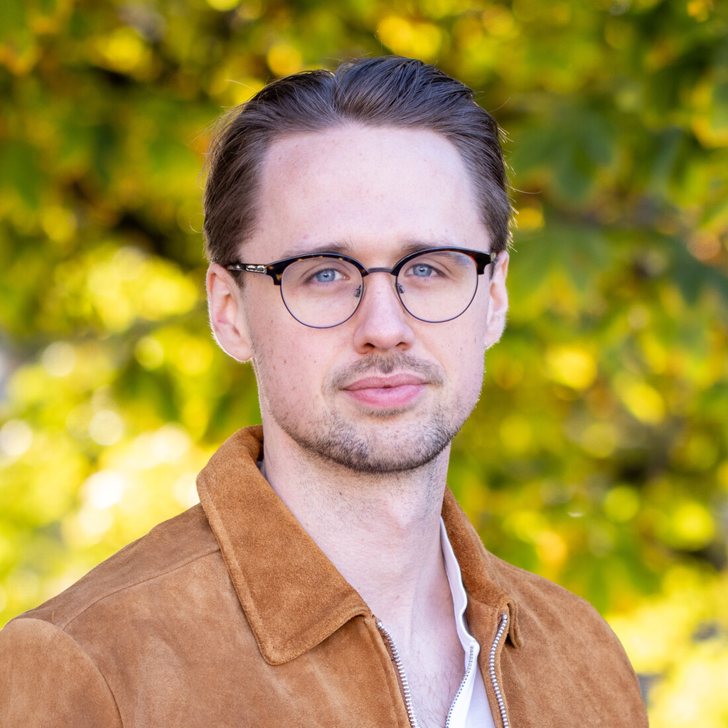